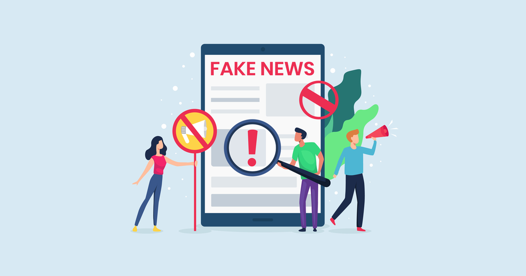

# Introduction

Fake news is a broad term and in this project specifically in this notebook, we will dive into fake and real articles. We will see what the data we have, how it was collected then we will have a basic understanding of the data. Next, we will explore the data by asking questions and coming up with hypotheses about the data. In addition to that, we shall analze a sample of data to see what potentional problems in the data. Last, we will display our findings in a short way to conclude the notebook.

## Problem understanding

News can be in many different forms. For example, Newspapers, Magazines, TV and radio, Internet, News agencies and Alternative media. Now, there are some businesses that try to promote their products or to advertise a product and some publish fake, attractive or charming news as 'clickbait' and we tend to be curious when it comes to unusual things and so we read / check the content. For instance, in 1835 newspaper company claimed that they have found out creates live in moon (humans with wings) [here is link for full article](https://www.newyorker.com/books/page-turner/moon-shot-race-a-hoax-and-the-birth-of-fake-news). That as a consequence allowed the company to be more popular which allowed them to promote and advertise more. Now this is one of the reasons why would certain group of people / a person publish fake news or misleading information. However, the influnce on the reader is usually harmful. For example, it could be that fake news regards healthy food suggest or recommend some types of food for people who suffer from kind of illness and if reader followed the suggestions that could be in fact harmful for them since news were fake in the first place. There are more scenarios obviously but this is where the problem lies. Fake news in general are published for the sake of obtaining profit most of the time and readers might believe misleading information which could influence their decisions.

In this research though, the focus will be on the news of covid-19 topic (tweets) and various topics of fake, legit articles published on the internet.

## Research question

- Based on the classified online articles as fake and real 'How is it possible to predict whether a new article tends to be fake or real?'

With this question in mind, the part of predicting the reliability of online articles should be clear (half of the project) and the other half (fake and legit fake tweets) will be in another notebook.

## Expectations of this notebook

After reading this notebook you should have:

- Understood the dataset at hand regarding online articles.
- Understood how the data was collected.
- Basic understanding of the data.
- Understood different questions used to explore the data.
- Conclusions whether some hypotheses were correct or incorrect.

# Table of content

## Table of content:

- Introduction
- Data requirement
- Data collection
- Loading libraries and the dataset
- Basic understanding of data
- Exploratory data analysis
- Conclusions

# Data requirement

In this section I will describe the obtained data, its format, the number of columns and rows in addition to a description of each column.

## Description of obtained data

The dataset is about online articles which was taken from fake articles [kaggle](https://www.kaggle.com/mrisdal/fake-news) dataset and real articles from [All Sides](https://www.allsides.com/unbiased-balanced-news) during 2015 and 2016. The dataset I am currently using is the one after it has been merged, check out the Data Gather/Wrangling [part](https://opendatascience.com/how-to-build-a-fake-news-classification-model/)

## Format of the data

The acquired dataset of online articles is in CSV-format which can be easily stored locally on the machine.

## General information about the dataset

The columns being as the following:

- **Unnamed: 0**, which represents a unique number for each article in the dataset.
- **title**, which represents the title of the online article.
- **text**, which represent the context or the body of the online article.
- **label**, which represents whether an article was considered to be fake or real.

# Data collection

In this section I will describe where, how the data was acquired and pontential problems could arise while attempting to acquire them in addition to some remarks.

## Where the data can be obtained?

The data can be obtained through this [link](https://github.com/ricknta/fake-news), which is a github repository where the dataset owner has uploaded as an open-source.

The dataset file name: fake_or_real_news.csv.zip

## How the data can be obtained?

In the previous sub-section I provided a link to where the data can be obtained. However, after clicking the link you will need to either download the entire repository as ZIP file or use git to get the repository in your local machine. Please follow one of the two possible twos:

1. recommend way (ZIP file)

[figure not shown]

[figure not shown]

1. Cloning the repository:
- This way you will be able to clone a copy of the entire repository via git command line. (first you will have to dowbload [git](https://git-scm.com/downloads)).
- Open a folder you desire to have the cloned repository in.
- Copy the repository link.
- Open the git commander and type 'git clone (repository link)' and hit enter.

Please consider the following pictures for clarification:

[figure not shown]

[figure not shown]

[figure not shown]

[figure not shown]

## Potential problems can be encountered?

- The second approach of obtaining the repository can be a bit difficult to people who never worked with git before, therefore they can receive errors in command line due to some type errors or incorrect git setup. A common issue is that they would need to setup their global name and email before they can clone. So I would suggest searching about git and how to set it up correctly in your local machine. It is a powerful version control system but can be tricky for beginners.

## Remarks

- After downloading the repository the dataset is in .csv.zip file extension which needs to be renamed to .csv in order to work with the data.
- The data contains the label column which was assigned by kaggle fake online articles and real articles taken from allsides. The merged dataset in its final form was provided in this research.
- The data contains the 'Unnamed: 0' column which represent a unique identifier and that can be dropped since we would not use it probably.

# Loading libraries and the dataset

```python
import matplotlib.pyplot as plt
import seaborn as sns
import numpy as np
import pandas as pd
import re
import nltk
from nltk.corpus import stopwords
from nltk.stem.porter import PorterStemmer
from nltk.stem import WordNetLemmatizer
import spacy

nlp = spacy.load('en_core_web_sm')

from langdetect import detect, DetectorFactory
DetectorFactory.seed = 0


from wordcloud import WordCloud
from textwrap import wrap

from sklearn.feature_extraction.text import CountVectorizer
```

```python
df = pd.read_csv('fake_or_real_news.csv')
```

## Explanation of the imported libraries

**Matplotlib**, Matplotlib is a comprehensive library for creating static, animated, and interactive visualizations in Python. Matplotlib makes easy things easy and hard things possible.

**Seaborn** Seaborn is a Python data visualization library based on matplotlib. It provides a high-level interface for drawing attractive and informative statistical graphics.

**Numpy** It is a Python library that provides a multidimensional array object, various derived objects (such as masked arrays and matrices), and an assortment of routines for fast operations on arrays, including mathematical, logical, shape manipulation, sorting, selecting, I/O, discrete Fourier transforms, basic linear algebra, basic statistical operations, random simulation and much more.

**Pandas** pandas is a fast, powerful, flexible and easy to use open source data analysis and manipulation tool, built on top of the Python programming language.

**re** A regular expression (or RE) specifies a set of strings that matches it; the functions in this module let you check if a particular string matches a given regular expression

**nltk** NLTK is a leading platform for building Python programs to work with human language data. It provides easy-to-use interfaces to over 50 corpora and lexical resources such as WordNet, along with a suite of text processing libraries for classification, tokenization, stemming, tagging, parsing, and semantic reasoning, wrappers for industrial-strength NLP libraries, and an active discussion forum.

**spacy** spaCy is a free open-source library for Natural Language Processing in Python. It features NER, POS tagging, dependency parsing, word vectors and more.

**langdetect** A python library that allows you to identify the language in a given string.

**wordcloud** Word Cloud is a data visualization technique used for representing text data in which the size of each word indicates its frequency or importance.

**CountVectorizer** CountVectorizer is a great tool provided by the scikit-learn library in Python. It is used to transform a given text into a vector on the basis of the frequency (count) of each word that occurs in the entire text.

# Basic understanding of data

In this section of this notebook, I shall check basic information about the dataset such as its shape, first a few data rows, column names, general information about the dataset and a description of the data. Then, I will conclude the findings at the end of the section.

```python
df.shape
```

```
(6335, 4)
```

```python
df.head()
```

|  | Unnamed: 0 | title | text | label |
| --- | --- | --- | --- | --- |
| 0 | 8476 | You Can Smell Hillary’s Fear | Daniel Greenfield, a Shillman Journalism Fello... | FAKE |
| 1 | 10294 | Watch The Exact Moment Paul Ryan Committed Pol... | Google Pinterest Digg Linkedin Reddit Stumbleu... | FAKE |
| 2 | 3608 | Kerry to go to Paris in gesture of sympathy | U.S. Secretary of State John F. Kerry said Mon... | REAL |
| 3 | 10142 | Bernie supporters on Twitter erupt in anger ag... | — Kaydee King (@KaydeeKing) November 9, 2016 T... | FAKE |
| 4 | 875 | The Battle of New York: Why This Primary Matters | It's primary day in New York and front-runners... | REAL |

```python
df.columns
```

```
Index(['Unnamed: 0', 'title', 'text', 'label'], dtype='object')
```

```python
df.info()
```

```
<class 'pandas.core.frame.DataFrame'>
RangeIndex: 6335 entries, 0 to 6334
Data columns (total 4 columns):
 #   Column      Non-Null Count  Dtype
---  ------      --------------  -----
 0   Unnamed: 0  6335 non-null   int64
 1   title       6335 non-null   object
 2   text        6335 non-null   object
 3   label       6335 non-null   object
dtypes: int64(1), object(3)
memory usage: 198.1+ KB
```

The following code only have title, text and label since they non-numerical columns. Since, if the 'Unnamed 0' (which stands for id of the article) was included that would change the behaviour of describe method thus we will not derive useful information afterwards.

```python
df[['title','text','label']].describe()
```

|  | title | text | label |
| --- | --- | --- | --- |
| count | 6335 | 6335 | 6335 |
| unique | 6256 | 6060 | 2 |
| top | OnPolitics \| 's politics blog | Killing Obama administration rules, dismantlin... | REAL |
| freq | 5 | 58 | 3171 |

```python
df.label.value_counts()
```

```
REAL    3171
FAKE    3164
Name: label, dtype: int64
```

## Findings

The data set has 6335 rows, each represents an article. There are about 80 duplicate titles and 270 duplicated text article (body of the article). The amount of fake articles is almost equal to the amount of fake articles which indicate balance dataset.

# Exploratory data analysis

## Questions used to explore the data

The following are arising questions which I use to help me explore the dataset:

- What is the relationship between the reliability(fake/legit) and the length (characters) of the article?
- What is the relationship between the reliability(fake/legit) and the length (words) of the article?
- What is the relationship between the reliability(fake/legit) and the length (sentences) of the article?
- What are top common words that appear real and fake online articles?
- What kind of problems can be found in the tweet text ? (which can be fixed in the data preparation pre-processing part)

## hypothesis

The following are my hypotheses regarding the questions mentioned the in the previous sub-section:

- I think that if the article has more length, it should be leaning towards truth because more length means more information being displayed and more clarification to the subject.

## Exploring the length of tweets

In this part of exploratory data analysis I shall visualize the length of chatacters, words and sentences with the reliability label and conclude whether my hyothesis regarding that was correct or not.

### Feature engineering (creating length per character, word and sentence)

In this sub-section of exploratory data analysis I shall use feature engineering to create 3 columns which represent the number of characters, words and sentences in an article. Then, I will be demonstrating the statistics of those columns in addition to attempting to find out relationship between them and the reliability column (label). Last, I will conclude the sub-section by checking whether or not the hypothesis was correct.

```python
df["No_of_Characters"] = df["text"].apply(len)

df["No_of_Words"]=df.apply(lambda row: nltk.word_tokenize(row["text"]), axis=1).apply(len)

df["No_of_sentence"]=df.apply(lambda row: nltk.sent_tokenize(row["text"]), axis=1).apply(len)

df.describe().T
```

|  | count | mean | std | min | 25% | 50% | 75% | max |
| --- | --- | --- | --- | --- | --- | --- | --- | --- |
| Unnamed: 0 | 6335.0 | 5280.415627 | 3038.503953 | 2.0 | 2674.5 | 5271.0 | 7901.0 | 10557.0 |
| No_of_Characters | 6335.0 | 4707.250355 | 5090.956446 | 1.0 | 1741.5 | 3642.0 | 6192.0 | 115372.0 |
| No_of_Words | 6335.0 | 901.234728 | 991.374399 | 0.0 | 337.0 | 694.0 | 1185.5 | 23966.0 |
| No_of_sentence | 6335.0 | 34.313496 | 42.048503 | 0.0 | 12.0 | 25.0 | 45.0 | 1344.0 |

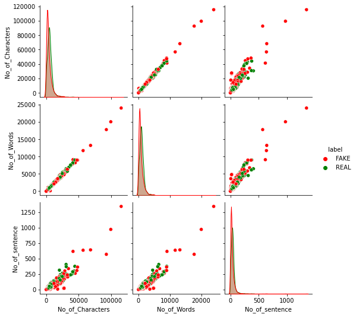

```python
cols= ["red", "green"]
df_subset = df[['No_of_Characters','No_of_Words','No_of_sentence','label']]
plt.figure(figsize=(12,8))
fg = sns.pairplot(data=df_subset, hue="label",palette=cols)
plt.show(fg)
```

It is not exactly clear what the relation is due to having outliers in each of character, word and sentence lengths. I will try to zoom in to see whether the picture gets clearer without the outliers.

**Note**: From above data visualization, it is clear to me that range of less than 25000 characters, less than 2000 characters and less than 100 sentences would result in more informative graph.

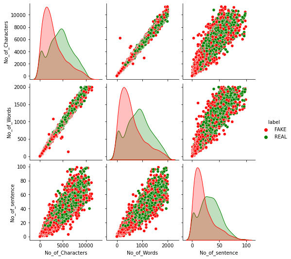

```python
df_subset = df[(df['No_of_Characters']< 25000) & (df['No_of_Words']< 2000) & (df['No_of_sentence']< 100)][['No_of_Characters','No_of_Words','No_of_sentence','label']]
plt.figure(figsize=(12,8))
fg = sns.pairplot(data=df_subset, hue="label",palette=cols)
plt.show(fg)
```

### Findings

After counting the number of characters, words and sentences for each article I tried to find out what was the relationship between the length and the reliability. I found out that in the dataset there are outliers in terms of length and if you zoom in to where outliers are not in your scope range you will notice that the more length of sentenecs, characters and words the more it leans towards being real article. On average articles that have 50 sentences, 1000 words orabout 5000 characters tend to be real.

**hypothesis**: I think that if the article has more length, it should be leaning towards truth because more length means more information being displayed and more clarification to the subject.

Therefore, the hypothesis was correct the data shows that the more length of an article the higher chance of it being real.

## top words that appear in fake tweets and real tweets

In this section I shall attempt to findout what are top words that used in fake articles and real articles and conclude the section with findings regarding this task.

### Group the articles according to their reliability

Here I will group the entire corpus of all fake articles into 1 large corpus and all real articles into 1 large corpus so that in next chapters I can perform what is known as Document Term Matrix, which indicates on the columns each possible word that was mentioned in one of the articles and its amount of occurences in row correspondingly. That will allow me to generate a cloud visualization to see important words mentioned in both fake and real articles.

```python
# group all fake tweets together and real tweets together
df_group=df[['text','label']].groupby(by='label').agg(lambda x:' '.join(x))
df_group.head()
```

| label | text |
| --- | --- |
| FAKE | Daniel Greenfield, a Shillman Journalism Fello... |
| REAL | U.S. Secretary of State John F. Kerry said Mon... |

### Visualize the corpse

In this sub-section I will use the grouped article text for each label (each corpus) and transform it into a matrix where each word indicate how important it is to the corpus and finally use WordCloud as data visualization to see important words for each label.

The following function takes in the data and title to spit out word cloud data visualization

```python
# Function for generating word clouds
def generate_wordcloud(data,title):
  wc = WordCloud(width=400, height=330, max_words=150,colormap="Dark2").generate_from_frequencies(data)
  plt.figure(figsize=(10,8))
  plt.imshow(wc, interpolation='bilinear')
  plt.axis("off")
  plt.title('\n'.join(wrap(title,60)),fontsize=13)
  plt.show()
```

I will create now a matrix where each row represent a word that was present in the corpus of each fake and real with the corresponding reliability. Also stop words such as 'The, I, you' are words that occur too often but does not actually influence what we are trying to do therefore I will remove them in the CountVectorizer parameter.

```python
cv=CountVectorizer(analyzer='word',stop_words ='english')
data=cv.fit_transform(df_group['text'])
df_dtm = pd.DataFrame(data.toarray(), columns=cv.get_feature_names())
df_dtm.index=df_group.index
df_dtm=df_dtm.transpose()
df_dtm.sample(3)
```

| label | FAKE | REAL |
| --- | --- | --- |
| symposium | 7 | 2 |
| mannerisms | 3 | 1 |
| misleading | 41 | 60 |

Now we will plot the words.

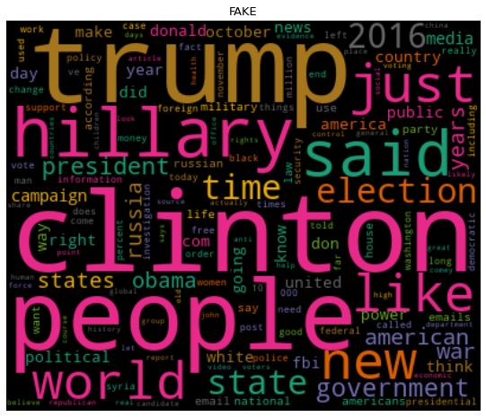

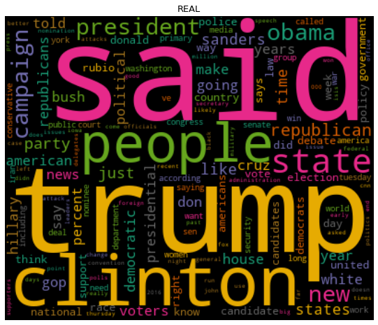

```python
for index,tweet in enumerate(df_dtm.columns):
  generate_wordcloud(df_dtm[tweet].sort_values(ascending=False),tweet)
```

## Finding out tweet text issues

In this section, I will be taking a sample of the tweets and check what could be problematic in the text and what are possible fixes.

```python
for index,text in enumerate(df['text'][45:50]):
  print('Article %d:\n\n'%(index+1),text)
```

```
Article 1:

 By Dan Zukowski
Three major U.S. pipeline spills within the last month are just a small part of the 220 significant incidents reported so far this year—and 3,032 since 2006—that provide a stark reminder of the environmental hazards of an aging pipeline infrastructure carrying fossil fuels. The costs of these leaks …
1. Oklahoma: On Oct. 24, the 30-inch S-1 pipeline carrying crude oil from the critical Cushing, Oklahoma hub to refineries and chemical plants on the Gulf Coast began to leak and was shut down overnight. It was the second release connected with the Cushing storage facility in less than a month.
2. Pennsylvania: On Oct. 21, 55,000 gallons of gasoline gushed from a ruptured Sunoco Logistics pipeline in Williamsport, Pennsylvania, just upstream from the Susquehanna River. Carol Parenzan, Middle Susquehanna Riverkeeper , said that witnesses who contacted her office reported that the “smell of …
3. Alabama: Last month, the Colonial Pipeline in Alabama leaked an estimated 336,000 gallons of gasoline and triggered concerns about gas shortages for drivers in the East. That spill was Colonial’s fifth in the state this year and occurred on a 43-year old section of the pipeline.
Based on data from the Pipeline and Hazardous Materials Safety Administration (PHMSA), an arm of the U.S. Department of Transportation, the number of significant pipeline incidents grew 26.8 percent from 2006 to 2015. A significant incident is defined as one that results in serious injury or fatalit…
Some 55 percent of the U.S. network of 135,000 miles of pipeline is more than 45 years old. Technology designed to detect pipeline leaks is highly unreliable, even though companies like Colonial Pipeline tout their use as a way “to insure safe operations.” But a recent Reuters report found that thes…
In testimony before a House subcommittee earlier this year, Carl Weimer, executive director of the watchdog group Pipeline Safety Trust , said, “Under the current statutes there is no requirement that a pipeline company obtain any permit or permission to operate a pipeline in this country.” Weimer c…
“It is important that we not only maintain our aging energy infrastructure, but that we also remain vigilant about new pipelines and energy interests that threaten water quality,” said Parenzan.
Dan Zukowski — Environmental journalist and nature photographer. Member, Society of Environmental Journalists. Follow me on Twitter @DanZukowski and visit DBZ Photo
Source: EcoWatch

Article 2:

 The president now plans to continue a U.S. ground force presence in Afghanistan to help hold off the Taliban until he leaves office. This is an uncommon turnaround for a president who hasn’t changed his mind on foreign policy since drawing his (much-ballyhooed and promptly ignored) “red line” in Sy…

So what does this rare shift have to say about Obama’s foreign policy and America’s future role in Afghanistan? Not much.

Mr. Obama started his presidency hoping to use Afghanistan to demonstrate his willingness to roll up his sleeves and get his hands dirty in the national security business. He asserted that, unlike “Bush’s War” in Iraq, fighting in the place where the 9/11 attacks were concocted was worth it.

In approving a surge in Afghanistan, the president made much of his role as decider-in-chief. Yet, even as he sent in more troops, he tipped his hand that Afghanistan was not as much an exception to the talk-don’t-fight Obama Doctrine as the tough-guy image he sought to cultivate.

The president gave commanders only half the force and half the time they requested to do the job right. It turned out, the commanders were right.  Mr. Obama, however, had his eye on the next election and wanted to go into the race showing he had put the war on a glide-path to wind down and pull out.

Signaling a limited-time interest in fighting an enemy rarely ends well. The Taliban adopted the logical and predictable strategy of simply waiting out Mr. Obama. Also predictably, the half-measure surge and overly ambitious transfer of responsibility to the Afghan military resulted in unnecessarily…

Nevertheless, Afghanistan is far from a total failure. Indeed,  compared to the president’s other foreign policy dalliances—from the Russian “reset” to Libya to Syria to Iraq to Ukraine— it ranks as his best achievement yet.

Which is why Mr. Obama is reportedly backing away from his plan to yank virtually all U.S. troops out of Afghanistan by the end of next year. Instead, he has agreed to leave the current force of 9,800 troops in place throughout “most” of next year, and keep 5,500 in theater thereafter.

It’s a good call. With the Taliban flexing its muscles anew and the Islamic State making inroads there, completely pulling out makes little sense. Mr. Obama can ill afford another complete foreign policy disaster on his watch.  Further, virtually everyone –the U.S. military, the Afghans, Pakistan, I…

In addition, there is zero domestic pressure for the president to make good on his campaign promise. An appearance of Code Pink is about as common as a Yeti sighting. And in the debates thus far, presidential candidates have devoted about as much time to Afghanistan as they have to defunding Public …

It makes complete sense for Mr. Obama to tough it out in Afghanistan, but don’t expect the change in plans to make things better for the Afghans or the larger security picture. The U.S. presence is the bare minimum to hold on. More forces with loser rules of engagement would make the country much sa…

But holding on is probably the best we can hope for with this president.  Here’s hoping the next Commander in Chief’s attitude toward Afghanistan will focus more on solving problems than just wishing they would go away.

```

[output cut: 8 more lines]

```
Amir A, 20, was visiting the Theresienbad pool in the Austrian capital of Vienna last December as part of a trip to encourage integration.
When the youngster went to the showers, Amir A. allegedly followed him, pushed him into a toilet cubicle, and violently sexually assaulted him.
Following the attack, the accused rapist returned to the pool and was practising on the diving board when police arrived, after the 10-year-old raised the alarm with the lifeguard.
The child suffered severe anal injuries which had to be treated at a local children’s hospital, and is still plagued by serious post-traumatic stress disorder.
In a police interview, Amir A. confessed to the crime; telling officers the incident had been “a sexual emergency”, as his wife had remained in Iraq and he “had not had sex in four months”.
A court found Amir guilty of serious sexual assault and rape of a minor, and sentenced him to six years in jail.
However, in
Article 5:

 Breaking News Pieczenik “Rogue FBI Agents and Wikileaks are Spearheading a Movement to Stop the Clintons from Stealing the White House” Pieczenik “Rogue FBI Agents and Wikileaks are Spearheading a Movement to Stop the Clintons from Stealing the White House” Breaking News By Amy Moreno November 2, 2…
The world is teaming up to stop crooked Hillary from taking the White House.
From Wikileaks to rogue FBI agents, everyone is doing their part to stop the sinister Clinton Machine.
It’s a joint effort from patriots hailing from every corner of the world.
Watch the video: Breaking:Twitter Friendly Version A soft coup has been launched by FBI to overthrow the Clinton’s hostile takeover of the White House. pic.twitter.com/MrPUlSO1OE
— OakTown ☢MAGA O.G☢ (@hrtablaze) November 2, 2016 This is a movement – we are the political OUTSIDERS fighting against the FAILED GLOBAL ESTABLISHMENT! Join the resistance and help us fight to put America First! Amy Moreno is a Published Author , Pug Lover & Game of Thrones Nerd. You can follow her…
```

### Things to be noticed

**Note**: Keep in mind that the model that is going to be created should give results according to keywords of the articles, thus digits should not matter. Distinguishing 'fake' or 'real' articles based on keywords is possible but not with digits included (atleast in my project).

### Findings

After analyzing a sample of the data we have derived that the text contain some problems such as capalization, punctuations, short contractions (example, It's), a few emojis in the text and the text contain digits which would not be useful for us in the prediction section.

Therefore the list of fixes for the text as follows:

1. Lowercase all the text
2. Expand Contractions
3. Remove punctuations
4. Remove emojis
5. Remove digits

After that we should have clean text, but in order to continue processing it we would need to remove stopwords as they appear often in text corpus while not indicating actual meaning and need to use lemmatization technique in order to bring the words from various tense forms into their base form (example. 'Went' --use lemma--> 'Go')

# Conclusions

To conclude this notebook, although fake news is a broad term our focus in this research was on online articles and covid-19 tweets (which is covered in different notebook.), fake news in general are published for the sake of obtaining profit most of the time and readers might believe misleading information which could influence their decisions.

The data we worked on contains 4 columns Unnamed 0,title,text and label around 6335 rows while Unnamed 0 indicate a unique identifier, title indicates the title of the article,text indicate body of the article and the label indicate the reliability of the article. The current dataset is a merged balanced data provided as open-source for purposes of classifying fake and real articles. The dataset can be easily stored in machine locally due to its size and its format. There are some duplicated titles and body (text) of articles

On average articles that have 50 sentences, 1000 words orabout 5000 characters tend to be real. Words such as election, president, hillary and government appear often in fake articles. While, words such as voters, democratic, political and law appear often in real articles. The dominating topic of articles in the dataset lean towards politics and election.

The dataset contain text issues which can be fixed with the following methods:

1. Lowercase all the text
2. Expand Contractions
3. Remove punctuations
4. Remove emojis
5. Remove digits